# ef04e630-8e7a-49ec-9070-fc72625558dd-Copy1

**Описание проекта "Исследование поведения клиентов компании «Пока все ещё тут»"**

Данный проект направлен на исследование и анализ данных интернет-магазина товаров для дома «Пока все ещё тут»

**Ссылка на презентацию - https://drive.google.com/file/d/1rWq7R4TucvR8ctfh7l0LJzssLW1lLRCe/view?usp=sharing**

**Цели исследования**

- Оценить ключевые показатели работы магазина за выбранный период
- Провести анализ ассортимента товаров и выделить основные товарные категории
- Сегментировать покупателей на основе их поведения и покупательской активности
- Провести сравнение сегментов по ключевым метрикам
- Проверить статистические гипотезы о различиях между сегментами
- Сформировать рекомендации по персонализации, маркетингу и работе с клиентами

**Шаг 1. Предобработка данных**

Импортируем необходимые библиотеки

```python
import pandas as pd
import datetime as dt
import numpy as np
import matplotlib.pyplot as plt
from pandas.plotting import register_matplotlib_converters
import scipy.stats as st
import math
import seaborn as sns
import re
from scipy.stats import mannwhitneyu
from itertools import combinations
import matplotlib.dates as mdates
from statsmodels.stats.multitest import multipletests
```

Изучим основную информацию о данных

```python
data = pd.read_csv('/datasets/ecom_dataset_upd.csv')
data
```

|  | date | customer_id | order_id | product | quantity | price |
| --- | --- | --- | --- | --- | --- | --- |
| 0 | 2018100100 | ee47d746-6d2f-4d3c-9622-c31412542920 | 68477 | Комнатное растение в горшке Алое Вера, d12, h30 | 1 | 142.0 |
| 1 | 2018100100 | ee47d746-6d2f-4d3c-9622-c31412542920 | 68477 | Комнатное растение в горшке Кофе Арабика, d12,... | 1 | 194.0 |
| 2 | 2018100100 | ee47d746-6d2f-4d3c-9622-c31412542920 | 68477 | Радермахера d-12 см h-20 см | 1 | 112.0 |
| 3 | 2018100100 | ee47d746-6d2f-4d3c-9622-c31412542920 | 68477 | Хризолидокарпус Лутесценс d-9 см | 1 | 179.0 |
| 4 | 2018100100 | ee47d746-6d2f-4d3c-9622-c31412542920 | 68477 | Циперус Зумула d-12 см h-25 см | 1 | 112.0 |
| ... | ... | ... | ... | ... | ... | ... |
| 7469 | 2020013021 | 63208953-a8e4-4f77-9b47-3a46e7b72eee | 104002 | томата (помидор) Черниченский черри № 116 сорт... | 2 | 38.0 |
| 7470 | 2020013022 | d99d25f1-4017-4fcd-8d29-c580cc695a1a | 107336 | Дендробиум Санок Анна Грин 1 ствол d-12 см | 1 | 869.0 |
| 7471 | 2020013102 | 2c9bd08d-8c55-4e7a-9bfb-8c56ba42c6d6 | 106336 | Подставка для обуви резиновая Attribute 80x40 ... | 1 | 354.0 |
| 7472 | 2020013112 | cdd17932-623e-415f-a577-3b31312fd0e2 | 102002 | Тагетис крупноцветковый рассада однолетних цве... | 1 | 128.0 |
| 7473 | 2020013115 | 2e460a26-35af-453d-a369-a036e95a40e0 | 103225 | Вешалка для блузок 41 см красный Attribute AHM781 | 1 | 104.0 |

7474 rows × 6 columns

```python
data.info()
```

```
<class 'pandas.core.frame.DataFrame'>
RangeIndex: 7474 entries, 0 to 7473
Data columns (total 6 columns):
 #   Column       Non-Null Count  Dtype
---  ------       --------------  -----
 0   date         7474 non-null   int64
 1   customer_id  7474 non-null   object
 2   order_id     7474 non-null   int64
 3   product      7474 non-null   object
 4   quantity     7474 non-null   int64
 5   price        7474 non-null   float64
dtypes: float64(1), int64(3), object(2)
memory usage: 350.5+ KB
```

Преобразуем формат даты, предварительно избавимся от ненужных двух нулей в конце

```python
data['date'] = data['date'].astype(str).str[:8]
data['date']
```

```
0       20181001
1       20181001
2       20181001
3       20181001
4       20181001
          ...
7469    20200130
7470    20200130
7471    20200131
7472    20200131
7473    20200131
Name: date, Length: 7474, dtype: object
```

```python
data['date'] = pd.to_datetime(data['date']).dt.date
data
```

|  | date | customer_id | order_id | product | quantity | price |
| --- | --- | --- | --- | --- | --- | --- |
| 0 | 2018-10-01 | ee47d746-6d2f-4d3c-9622-c31412542920 | 68477 | Комнатное растение в горшке Алое Вера, d12, h30 | 1 | 142.0 |
| 1 | 2018-10-01 | ee47d746-6d2f-4d3c-9622-c31412542920 | 68477 | Комнатное растение в горшке Кофе Арабика, d12,... | 1 | 194.0 |
| 2 | 2018-10-01 | ee47d746-6d2f-4d3c-9622-c31412542920 | 68477 | Радермахера d-12 см h-20 см | 1 | 112.0 |
| 3 | 2018-10-01 | ee47d746-6d2f-4d3c-9622-c31412542920 | 68477 | Хризолидокарпус Лутесценс d-9 см | 1 | 179.0 |
| 4 | 2018-10-01 | ee47d746-6d2f-4d3c-9622-c31412542920 | 68477 | Циперус Зумула d-12 см h-25 см | 1 | 112.0 |
| ... | ... | ... | ... | ... | ... | ... |
| 7469 | 2020-01-30 | 63208953-a8e4-4f77-9b47-3a46e7b72eee | 104002 | томата (помидор) Черниченский черри № 116 сорт... | 2 | 38.0 |
| 7470 | 2020-01-30 | d99d25f1-4017-4fcd-8d29-c580cc695a1a | 107336 | Дендробиум Санок Анна Грин 1 ствол d-12 см | 1 | 869.0 |
| 7471 | 2020-01-31 | 2c9bd08d-8c55-4e7a-9bfb-8c56ba42c6d6 | 106336 | Подставка для обуви резиновая Attribute 80x40 ... | 1 | 354.0 |
| 7472 | 2020-01-31 | cdd17932-623e-415f-a577-3b31312fd0e2 | 102002 | Тагетис крупноцветковый рассада однолетних цве... | 1 | 128.0 |
| 7473 | 2020-01-31 | 2e460a26-35af-453d-a369-a036e95a40e0 | 103225 | Вешалка для блузок 41 см красный Attribute AHM781 | 1 | 104.0 |

7474 rows × 6 columns

Проверим данные на пропуски

```python
data.isna().sum()
```

```
date           0
customer_id    0
order_id       0
product        0
quantity       0
price          0
dtype: int64
```

Пропуски отсутствуют

Проверим данные на явные дубликаты

```python
print(f"Количество явных дубликатов: {data.duplicated().sum()}")
```

```
Количество явных дубликатов: 966
```

Удалим явные дубликаты

```python
data.drop_duplicates()
```

|  | date | customer_id | order_id | product | quantity | price |
| --- | --- | --- | --- | --- | --- | --- |
| 0 | 2018-10-01 | ee47d746-6d2f-4d3c-9622-c31412542920 | 68477 | Комнатное растение в горшке Алое Вера, d12, h30 | 1 | 142.0 |
| 1 | 2018-10-01 | ee47d746-6d2f-4d3c-9622-c31412542920 | 68477 | Комнатное растение в горшке Кофе Арабика, d12,... | 1 | 194.0 |
| 2 | 2018-10-01 | ee47d746-6d2f-4d3c-9622-c31412542920 | 68477 | Радермахера d-12 см h-20 см | 1 | 112.0 |
| 3 | 2018-10-01 | ee47d746-6d2f-4d3c-9622-c31412542920 | 68477 | Хризолидокарпус Лутесценс d-9 см | 1 | 179.0 |
| 4 | 2018-10-01 | ee47d746-6d2f-4d3c-9622-c31412542920 | 68477 | Циперус Зумула d-12 см h-25 см | 1 | 112.0 |
| ... | ... | ... | ... | ... | ... | ... |
| 7469 | 2020-01-30 | 63208953-a8e4-4f77-9b47-3a46e7b72eee | 104002 | томата (помидор) Черниченский черри № 116 сорт... | 2 | 38.0 |
| 7470 | 2020-01-30 | d99d25f1-4017-4fcd-8d29-c580cc695a1a | 107336 | Дендробиум Санок Анна Грин 1 ствол d-12 см | 1 | 869.0 |
| 7471 | 2020-01-31 | 2c9bd08d-8c55-4e7a-9bfb-8c56ba42c6d6 | 106336 | Подставка для обуви резиновая Attribute 80x40 ... | 1 | 354.0 |
| 7472 | 2020-01-31 | cdd17932-623e-415f-a577-3b31312fd0e2 | 102002 | Тагетис крупноцветковый рассада однолетних цве... | 1 | 128.0 |
| 7473 | 2020-01-31 | 2e460a26-35af-453d-a369-a036e95a40e0 | 103225 | Вешалка для блузок 41 см красный Attribute AHM781 | 1 | 104.0 |

6508 rows × 6 columns

Проверим данные на неявные дубликаты

```python
duplicate_orders = data.groupby(['order_id', 'customer_id', 'date', 'product']).size()
duplicate_orders = duplicate_orders[duplicate_orders > 1]

display(duplicate_orders)
```

```
order_id  customer_id                           date        product
14500     3ee43256-af7d-4036-90d4-eeefa1afc767  2018-10-28  Многолетнее растение Душица-орегано розовый объем 0,5 л              2
                                                            Многолетнее растение Тимьян-чабрец розовый объем 0,5 л               2
                                                            Пеларгония зональная диам. 12 см белая полумахровая                  2
                                                            Пеларгония зональная диам. 12 см розовая с малиновым полумахровая    2
                                                            Пеларгония зональная диам. 12 см сиреневый полумахровый              2
                                                                                                                                ..
73095     56710968-02ea-46b7-9638-0ad9fa8544d0  2019-10-26  Тимьян d-9 см                                                        2
73101     f0fe3add-04d4-4488-8852-7e9e25b95fe9  2019-10-27  Хлорофитум d-7 см h-10 см укорененный черенок                        2
73104     b89ace7f-7017-408c-8755-c4ff39b50980  2019-10-27  Циперус Зумула d-12 см h-25 см                                       2
73108     cb65d08a-dae7-4890-aef0-bb9f79055e02  2019-10-28  Мирт d-9 см h-15 см                                                  2
73136     ffaeab76-3a8d-49ee-860f-17273b2fc8a2  2019-10-31  Таз пластмассовый со стиральной доской (Иж), 1404021                 2
Length: 543, dtype: int64
```

Удалим неявные дубликаты

```python
order_date_counts = data.groupby('order_id')['date'].nunique() # Группируем по order_id и смотрим уникальное количество дат
orders_with_multiple_dates = order_date_counts[order_date_counts > 1].index
```

```python
sample_orders = data[data['order_id'].isin(orders_with_multiple_dates)]
print(sample_orders.sort_values(by=['order_id', 'date']))
```

```
            date                           customer_id  order_id  \
102   2018-10-05  b80e4826-7218-4bf9-ac08-eb2c81ab3f62     13547
103   2018-10-05  b80e4826-7218-4bf9-ac08-eb2c81ab3f62     13547
104   2018-10-05  b80e4826-7218-4bf9-ac08-eb2c81ab3f62     13547
376   2018-10-23  b80e4826-7218-4bf9-ac08-eb2c81ab3f62     13547
377   2018-10-23  b80e4826-7218-4bf9-ac08-eb2c81ab3f62     13547
...          ...                                   ...       ...
6716  2019-10-30  ffaeab76-3a8d-49ee-860f-17273b2fc8a2     73136
6728  2019-10-31  ffaeab76-3a8d-49ee-860f-17273b2fc8a2     73136
6729  2019-10-31  ffaeab76-3a8d-49ee-860f-17273b2fc8a2     73136
6717  2019-10-30  344aa778-e436-419e-a9c6-9b8f37b7c1df     73137
6736  2019-10-31  344aa778-e436-419e-a9c6-9b8f37b7c1df     73137

                                                product  quantity   price
102   Рассада зелени для кухни Лаванды в кассете по ...         1   315.0
103   Рассада зелени для кухни Розмарина в кассете п...         1   207.0
104   Рассада зелени для кухни Тимьяна в кассете по ...         1   162.0
376   Рассада зелени для кухни Лаванды в кассете по ...         1   315.0
377   Рассада зелени для кухни Розмарина в кассете п...         1   207.0
...                                                 ...       ...     ...
6716  Таз пластмассовый со стиральной доской (Иж), 1...         1   397.0
6728  Таз пластмассовый со стиральной доской (Иж), 1...         1   397.0
6729  Таз пластмассовый со стиральной доской (Иж), 1...         1   397.0
6717         Сумка-тележка 2-х колесная Gimi Argo синяя         1  1087.0
6736         Сумка-тележка 2-х колесная Gimi Argo синяя         1  1087.0

[2213 rows x 6 columns]
```

```python
data_sorted = data.sort_values(by='date') # Сортируем по дате (чтобы поздняя дата шла последней)
data_cleaned = data_sorted.drop_duplicates(subset=['order_id', 'product'], keep='last') # Удаляем дубликаты, оставляя последнюю запись
```

```python
data_cleaned
```

|  | date | customer_id | order_id | product | quantity | price |
| --- | --- | --- | --- | --- | --- | --- |
| 0 | 2018-10-01 | ee47d746-6d2f-4d3c-9622-c31412542920 | 68477 | Комнатное растение в горшке Алое Вера, d12, h30 | 1 | 142.0 |
| 13 | 2018-10-01 | 0948b0c2-990b-4a11-b835-69ac4714b21d | 68486 | Крючок одежный 2-х рожковый серый металлик с п... | 96 | 38.0 |
| 12 | 2018-10-01 | 4d93d3f6-8b24-403b-a74b-f5173e40d7db | 68485 | Чехол Eurogold Clean Basic хлопок для досок 12... | 1 | 187.0 |
| 11 | 2018-10-01 | 86432d8d-b706-463b-bd5d-6a9e170daee3 | 68484 | Сушилка для белья потолочная Zalger Lift Basic... | 1 | 614.0 |
| 10 | 2018-10-01 | 161e1b98-45ba-4b4e-8236-e6e3e70f6f7c | 68483 | Вешалка для брюк металлическая с резиновым пок... | 10 | 82.0 |
| ... | ... | ... | ... | ... | ... | ... |
| 7469 | 2020-01-30 | 63208953-a8e4-4f77-9b47-3a46e7b72eee | 104002 | томата (помидор) Черниченский черри № 116 сорт... | 2 | 38.0 |
| 7470 | 2020-01-30 | d99d25f1-4017-4fcd-8d29-c580cc695a1a | 107336 | Дендробиум Санок Анна Грин 1 ствол d-12 см | 1 | 869.0 |
| 7472 | 2020-01-31 | cdd17932-623e-415f-a577-3b31312fd0e2 | 102002 | Тагетис крупноцветковый рассада однолетних цве... | 1 | 128.0 |
| 7471 | 2020-01-31 | 2c9bd08d-8c55-4e7a-9bfb-8c56ba42c6d6 | 106336 | Подставка для обуви резиновая Attribute 80x40 ... | 1 | 354.0 |
| 7473 | 2020-01-31 | 2e460a26-35af-453d-a369-a036e95a40e0 | 103225 | Вешалка для блузок 41 см красный Attribute AHM781 | 1 | 104.0 |

5554 rows × 6 columns

Добавим столбец с выручкой

```python
data_cleaned['revenue'] = data_cleaned['quantity'] * data_cleaned['price']
data_cleaned
```

|  | date | customer_id | order_id | product | quantity | price | revenue |
| --- | --- | --- | --- | --- | --- | --- | --- |
| 0 | 2018-10-01 | ee47d746-6d2f-4d3c-9622-c31412542920 | 68477 | Комнатное растение в горшке Алое Вера, d12, h30 | 1 | 142.0 | 142.0 |
| 13 | 2018-10-01 | 0948b0c2-990b-4a11-b835-69ac4714b21d | 68486 | Крючок одежный 2-х рожковый серый металлик с п... | 96 | 38.0 | 3648.0 |
| 12 | 2018-10-01 | 4d93d3f6-8b24-403b-a74b-f5173e40d7db | 68485 | Чехол Eurogold Clean Basic хлопок для досок 12... | 1 | 187.0 | 187.0 |
| 11 | 2018-10-01 | 86432d8d-b706-463b-bd5d-6a9e170daee3 | 68484 | Сушилка для белья потолочная Zalger Lift Basic... | 1 | 614.0 | 614.0 |
| 10 | 2018-10-01 | 161e1b98-45ba-4b4e-8236-e6e3e70f6f7c | 68483 | Вешалка для брюк металлическая с резиновым пок... | 10 | 82.0 | 820.0 |
| ... | ... | ... | ... | ... | ... | ... | ... |
| 7469 | 2020-01-30 | 63208953-a8e4-4f77-9b47-3a46e7b72eee | 104002 | томата (помидор) Черниченский черри № 116 сорт... | 2 | 38.0 | 76.0 |
| 7470 | 2020-01-30 | d99d25f1-4017-4fcd-8d29-c580cc695a1a | 107336 | Дендробиум Санок Анна Грин 1 ствол d-12 см | 1 | 869.0 | 869.0 |
| 7472 | 2020-01-31 | cdd17932-623e-415f-a577-3b31312fd0e2 | 102002 | Тагетис крупноцветковый рассада однолетних цве... | 1 | 128.0 | 128.0 |
| 7471 | 2020-01-31 | 2c9bd08d-8c55-4e7a-9bfb-8c56ba42c6d6 | 106336 | Подставка для обуви резиновая Attribute 80x40 ... | 1 | 354.0 | 354.0 |
| 7473 | 2020-01-31 | 2e460a26-35af-453d-a369-a036e95a40e0 | 103225 | Вешалка для блузок 41 см красный Attribute AHM781 | 1 | 104.0 | 104.0 |

5554 rows × 7 columns

```python
multi_customer_orders = data_cleaned.groupby('order_id')['customer_id'].nunique() #определяем заказы, у которых больше одного покупателя
bad_orders = multi_customer_orders[multi_customer_orders > 1].index
data_cleaned = data_cleaned[~data_cleaned['order_id'].isin(bad_orders)].copy() #удаляем строки, относящиеся к таким заказам
```

```python
data_cleaned
```

|  | date | customer_id | order_id | product | quantity | price | revenue |
| --- | --- | --- | --- | --- | --- | --- | --- |
| 0 | 2018-10-01 | ee47d746-6d2f-4d3c-9622-c31412542920 | 68477 | Комнатное растение в горшке Алое Вера, d12, h30 | 1 | 142.0 | 142.0 |
| 13 | 2018-10-01 | 0948b0c2-990b-4a11-b835-69ac4714b21d | 68486 | Крючок одежный 2-х рожковый серый металлик с п... | 96 | 38.0 | 3648.0 |
| 12 | 2018-10-01 | 4d93d3f6-8b24-403b-a74b-f5173e40d7db | 68485 | Чехол Eurogold Clean Basic хлопок для досок 12... | 1 | 187.0 | 187.0 |
| 11 | 2018-10-01 | 86432d8d-b706-463b-bd5d-6a9e170daee3 | 68484 | Сушилка для белья потолочная Zalger Lift Basic... | 1 | 614.0 | 614.0 |
| 10 | 2018-10-01 | 161e1b98-45ba-4b4e-8236-e6e3e70f6f7c | 68483 | Вешалка для брюк металлическая с резиновым пок... | 10 | 82.0 | 820.0 |
| ... | ... | ... | ... | ... | ... | ... | ... |
| 7469 | 2020-01-30 | 63208953-a8e4-4f77-9b47-3a46e7b72eee | 104002 | томата (помидор) Черниченский черри № 116 сорт... | 2 | 38.0 | 76.0 |
| 7470 | 2020-01-30 | d99d25f1-4017-4fcd-8d29-c580cc695a1a | 107336 | Дендробиум Санок Анна Грин 1 ствол d-12 см | 1 | 869.0 | 869.0 |
| 7472 | 2020-01-31 | cdd17932-623e-415f-a577-3b31312fd0e2 | 102002 | Тагетис крупноцветковый рассада однолетних цве... | 1 | 128.0 | 128.0 |
| 7471 | 2020-01-31 | 2c9bd08d-8c55-4e7a-9bfb-8c56ba42c6d6 | 106336 | Подставка для обуви резиновая Attribute 80x40 ... | 1 | 354.0 | 354.0 |
| 7473 | 2020-01-31 | 2e460a26-35af-453d-a369-a036e95a40e0 | 103225 | Вешалка для блузок 41 см красный Attribute AHM781 | 1 | 104.0 | 104.0 |

5552 rows × 7 columns

Проверим данные на аномалии

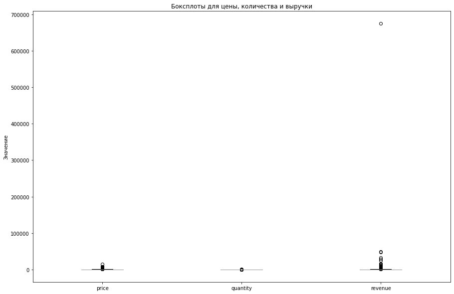

```python
plt.figure(figsize=(15, 10))
plt.boxplot([data_cleaned['price'], data_cleaned['quantity'], data_cleaned['revenue']], labels=['price', 'quantity', 'revenue'])
plt.title("Боксплоты для цены, количества и выручки")
plt.ylabel("Значение")
plt.show()
```

Заметен один большой выброс в столце выручки, из-за которого неудобно смотреть на графики, поэтому удалим его и снова посмотрим на графики